# DATA EXPLORATORY ANALSIS FOR CREDIT CARD DATA

# Business Problem:

In order to effectively produce quality decisions in the modern credit card industry, knowledge must be gained through effective data analysis and modelling. Through the use of dynamic data-driven decision-making tools and procedures, information can be gathered to successfully evaluate all aspects of credit card operations. PSPD Bank has banking operations in more than 50 countries across the globe. Mr. Jim Watson, CEO, wants to evaluate areas of bankruptcy, fraud and collections, respond to customer requests for help with proactive offers and services.

# IMPORT THE NECESSARY LIBRARIES

```python
import pandas as pd
import numpy as np
import matplotlib.pyplot as plt
import seaborn as sns
%matplotlib inline
import os
```

# IMPORT THE DATASETS

```python
customer = pd.read_csv(r"C:\Users\udayu\Downloads\archive (2)\CustomerAcqusition.csv",usecols=["Customer","Age","City","Product","Limit","Company","Segment"])
```

```python
repay=pd.read_csv(r"C:\Users\udayu\Downloads\archive (2)\Repayment.csv",usecols = ["Customer","Month","Amount"])
```

```python
spend=pd.read_csv(r"C:\Users\udayu\Downloads\archive (2)\spend.csv",usecols=["Customer","Month","Type","Amount"])
```

```python
customer.head()
```

|  | Customer | Age | City | Product | Limit | Company | Segment |
| --- | --- | --- | --- | --- | --- | --- | --- |
| 0 | A1 | 76 | BANGALORE | Gold | 500000.0 | C1 | Self Employed |
| 1 | A2 | 71 | CALCUTTA | Silver | 100000.0 | C2 | Salaried_MNC |
| 2 | A3 | 34 | COCHIN | Platimum | 10000.0 | C3 | Salaried_Pvt |
| 3 | A4 | 47 | BOMBAY | Platimum | 10001.0 | C4 | Govt |
| 4 | A5 | 56 | BANGALORE | Platimum | 10002.0 | C5 | Normal Salary |

```python
repay.head()
```

|  | Customer | Month | Amount |
| --- | --- | --- | --- |
| 0 | A1 | 12-Jan-04 | 495414.75 |
| 1 | A1 | 3-Jan-04 | 245899.02 |
| 2 | A1 | 15-Jan-04 | 259490.06 |
| 3 | A1 | 25-Jan-04 | 437555.12 |
| 4 | A1 | 17-Jan-05 | 165972.88 |

```python
spend.head()
```

|  | Customer | Month | Type | Amount |
| --- | --- | --- | --- | --- |
| 0 | A1 | 12-Jan-04 | JEWELLERY | 485470.80 |
| 1 | A1 | 3-Jan-04 | PETRO | 410556.13 |
| 2 | A1 | 15-Jan-04 | CLOTHES | 23740.46 |
| 3 | A1 | 25-Jan-04 | FOOD | 484342.47 |
| 4 | A1 | 17-Jan-05 | CAMERA | 369694.07 |

# EXPLORATORY DATA ANALYSIS

```python
print(customer.shape)
print(repay.shape)
print(spend.shape)
```

```
(100, 7)
(1523, 3)
(1500, 4)
```

```python
customer.dtypes
```

```
Customer     object
Age           int64
City         object
Product      object
Limit       float64
Company      object
Segment      object
dtype: object
```

```python
repay.dtypes
```

```
Customer     object
Month        object
Amount      float64
dtype: object
```

```python
spend.dtypes
```

```
Customer     object
Month        object
Type         object
Amount      float64
dtype: object
```

```python
spend.isnull().sum()
```

```
Customer    0
Month       0
Type        0
Amount      0
dtype: int64
```

```python
customer.isnull().sum()
```

```
Customer    0
Age         0
City        0
Product     0
Limit       0
Company     0
Segment     0
dtype: int64
```

```python
repay.isnull().sum()
```

```
Customer    23
Month       23
Amount      23
dtype: int64
```

```python
#Dropping null values present in 'repay' dataset
repay.dropna(inplace=True)
```

```python
repay.isnull().sum()
```

```
Customer    0
Month       0
Amount      0
dtype: int64
```

# (1) in the above dataset,

(a) in case age is less than 18, replace it with mean of age values

```python
mean_original=customer["Age"].mean()
```

```python
print("The mean of age column is :", mean_original)
```

```
The mean of age column is : 46.49
```

```python
#repalce age less than 18 with mean of age values
customer.loc[customer["Age"]<18,"Age"] =customer["Age"].mean()
```

```python
mean_new=customer["Age"].mean()
```

```python
print("The new mean of age column is:", mean_new)
```

```
The new mean of age column is: 48.39940000000001
```

```python
customer.loc[customer["Age"]<18,"Age"]
```

```
Series([], Name: Age, dtype: float64)
```

ALL THE CUSTOMER WHO HAVE AGE IS LESS THAN 18 YEARS HAVE BEEN REPLACED BY MEAN OF AGE COLUMN

# (B) IN CASE SPEND AMOUNT IS MORE THAN THE LIMIT, REPALCE IT WITH 50% OF CUSTOMER'S LIMIT.(CUSTOMER'S LIMIT PROVEDED IN ACQUISITION TABLE IS THE PER TRANSACTION LIMIT ON HIS CARD)

```python
customer.head(2)
```

|  | Customer | Age | City | Product | Limit | Company | Segment |
| --- | --- | --- | --- | --- | --- | --- | --- |
| 0 | A1 | 76.0 | BANGALORE | Gold | 500000.0 | C1 | Self Employed |
| 1 | A2 | 71.0 | CALCUTTA | Silver | 100000.0 | C2 | Salaried_MNC |

```python
spend.head(2)
```

|  | Customer | Month | Type | Amount |
| --- | --- | --- | --- | --- |
| 0 | A1 | 12-Jan-04 | JEWELLERY | 485470.80 |
| 1 | A1 | 3-Jan-04 | PETRO | 410556.13 |

```python
# merging customer and spend table on the basis of"customer" column
customer_spend=pd.merge(left=customer,right=spend,on="Customer",how="inner")
```

```python
customer_spend.head()
```

|  | Customer | Age | City | Product | Limit | Company | Segment | Month | Type | Amount |
| --- | --- | --- | --- | --- | --- | --- | --- | --- | --- | --- |
| 0 | A1 | 76.0 | BANGALORE | Gold | 500000.0 | C1 | Self Employed | 12-Jan-04 | JEWELLERY | 485470.80 |
| 1 | A1 | 76.0 | BANGALORE | Gold | 500000.0 | C1 | Self Employed | 3-Jan-04 | PETRO | 410556.13 |
| 2 | A1 | 76.0 | BANGALORE | Gold | 500000.0 | C1 | Self Employed | 15-Jan-04 | CLOTHES | 23740.46 |
| 3 | A1 | 76.0 | BANGALORE | Gold | 500000.0 | C1 | Self Employed | 25-Jan-04 | FOOD | 484342.47 |
| 4 | A1 | 76.0 | BANGALORE | Gold | 500000.0 | C1 | Self Employed | 17-Jan-05 | CAMERA | 369694.07 |

```python
customer_spend.shape
```

```
(1500, 10)
```

```python
#all the custmors whose spend amount is more than the limit, repalacing with 50% of that customers limit
customer_spend[customer_spend["Amount"]>customer_spend['Limit']]
```

|  | Customer | Age | City | Product | Limit | Company | Segment | Month | Type | Amount |
| --- | --- | --- | --- | --- | --- | --- | --- | --- | --- | --- |
| 18 | A2 | 71.0 | CALCUTTA | Silver | 100000.0 | C2 | Salaried_MNC | 3-Jan-04 | RENTAL | 199554.72 |
| 19 | A2 | 71.0 | CALCUTTA | Silver | 100000.0 | C2 | Salaried_MNC | 28-Feb-05 | TRAIN TICKET | 376887.49 |
| 20 | A2 | 71.0 | CALCUTTA | Silver | 100000.0 | C2 | Salaried_MNC | 6-Apr-04 | BUS TICKET | 439648.53 |
| 21 | A2 | 71.0 | CALCUTTA | Silver | 100000.0 | C2 | Salaried_MNC | 23-Nov-04 | PETRO | 384078.73 |
| 22 | A2 | 71.0 | CALCUTTA | Silver | 100000.0 | C2 | Salaried_MNC | 3-Sep-05 | JEWELLERY | 117089.16 |
| ... | ... | ... | ... | ... | ... | ... | ... | ... | ... | ... |
| 1486 | A87 | 27.0 | CALCUTTA | Silver | 100003.0 | C10 | Govt | 30-Mar-06 | RENTAL | 483886.62 |
| 1496 | A97 | 58.0 | TRIVANDRUM | Platimum | 10000.0 | C20 | Govt | 12-Jan-04 | AUTO | 139018.26 |
| 1497 | A98 | 51.0 | CALCUTTA | Platimum | 10001.0 | C21 | Normal Salary | 3-Jan-04 | SHOPPING | 284521.06 |
| 1498 | A99 | 35.0 | CALCUTTA | Platimum | 10002.0 | C22 | Self Employed | 15-Jan-04 | AIR TICKET | 90184.22 |
| 1499 | A100 | 36.0 | COCHIN | Silver | 100000.0 | C5 | Salaried_MNC | 25-Jan-04 | BUS TICKET | 224786.88 |

607 rows × 10 columns

```python
#if customer's spend amount is more than the limit,replacing with 50% of that customer’s limit
customer_spend.loc[customer_spend["Amount"] > customer_spend["Limit"],"Amount"] = (50 * customer_spend["Limit"]).div(100)
```

```python
#there are no customers left whose spend amount is more than the limit
customer_spend[customer_spend["Amount"] > customer_spend['Limit']]
```

|  | Customer | Age | City | Product | Limit | Company | Segment | Month | Type | Amount |
| --- | --- | --- | --- | --- | --- | --- | --- | --- | --- | --- |

# (C) incase the repayment amount is more than the limit, replace the repayment with the limit.

```python
customer.head(1)
```

|  | Customer | Age | City | Product | Limit | Company | Segment |
| --- | --- | --- | --- | --- | --- | --- | --- |
| 0 | A1 | 76.0 | BANGALORE | Gold | 500000.0 | C1 | Self Employed |

```python
repay.head(1)
```

|  | Customer | Month | Amount |
| --- | --- | --- | --- |
| 0 | A1 | 12-Jan-04 | 495414.75 |

```python
#merge customer and spend table on the baisi of "customer"column
customer_repay=pd.merge(left=repay,right=customer,on="Customer",how="inner")
```

```python
customer_repay.head()
```

|  | Customer | Month | Amount | Age | City | Product | Limit | Company | Segment |
| --- | --- | --- | --- | --- | --- | --- | --- | --- | --- |
| 0 | A1 | 12-Jan-04 | 495414.75 | 76.0 | BANGALORE | Gold | 500000.0 | C1 | Self Employed |
| 1 | A1 | 3-Jan-04 | 245899.02 | 76.0 | BANGALORE | Gold | 500000.0 | C1 | Self Employed |
| 2 | A1 | 15-Jan-04 | 259490.06 | 76.0 | BANGALORE | Gold | 500000.0 | C1 | Self Employed |
| 3 | A1 | 25-Jan-04 | 437555.12 | 76.0 | BANGALORE | Gold | 500000.0 | C1 | Self Employed |
| 4 | A1 | 17-Jan-05 | 165972.88 | 76.0 | BANGALORE | Gold | 500000.0 | C1 | Self Employed |

```python
#all the customers where repayment amount is more than the limit.
customer_repay[customer_repay["Amount"] > customer_repay["Limit"]]
```

|  | Customer | Month | Amount | Age | City | Product | Limit | Company | Segment |
| --- | --- | --- | --- | --- | --- | --- | --- | --- | --- |
| 18 | A8 | 5-Feb-04 | 156913.59 | 67.0 | PATNA | Silver | 100002.0 | C8 | Salaried_Pvt |
| 19 | A8 | 12-Jan-04 | 350999.98 | 67.0 | PATNA | Silver | 100002.0 | C8 | Salaried_Pvt |
| 20 | A8 | 31-Mar-06 | 155642.95 | 67.0 | PATNA | Silver | 100002.0 | C8 | Salaried_Pvt |
| 21 | A8 | 9-May-05 | 145457.38 | 67.0 | PATNA | Silver | 100002.0 | C8 | Salaried_Pvt |
| 22 | A8 | 8-May-06 | 361184.89 | 67.0 | PATNA | Silver | 100002.0 | C8 | Salaried_Pvt |
| ... | ... | ... | ... | ... | ... | ... | ... | ... | ... |
| 1494 | A7 | 6-May-06 | 400375.97 | 26.0 | COCHIN | Silver | 100001.0 | C7 | Salaried_MNC |
| 1496 | A7 | 3-Dec-05 | 429700.12 | 26.0 | COCHIN | Silver | 100001.0 | C7 | Salaried_MNC |
| 1497 | A7 | 23-Feb-05 | 344628.72 | 26.0 | COCHIN | Silver | 100001.0 | C7 | Salaried_MNC |
| 1498 | A7 | 31-Mar-06 | 336264.37 | 26.0 | COCHIN | Silver | 100001.0 | C7 | Salaried_MNC |
| 1499 | A7 | 3-Jan-04 | 473662.61 | 26.0 | COCHIN | Silver | 100001.0 | C7 | Salaried_MNC |

600 rows × 9 columns

```python
#customers where repayment amount is more than the limit, replacing the repayment with the limit.
customer_repay.loc[customer_repay["Amount"] > customer_repay["Limit"],"Amount"] = customer_repay["Limit"]

#there are no customers left where repayment amount is more than the limit.
customer_repay[customer_repay["Amount"] > customer_repay["Limit"]]
```

|  | Customer | Month | Amount | Age | City | Product | Limit | Company | Segment |
| --- | --- | --- | --- | --- | --- | --- | --- | --- | --- |

# 2 FROM THE ABOVE DATASET CREATE THE FOLLOWING SUMMARIES:

A. HOW THE MANY DISTINCT CUSTOMERS EXIST?

```python
distinct_customers=customer["Customer"].nunique()
```

```python
print("NUMBER OF DISTINCT CUSTOMERS ARE :" , distinct_customers)
```

```
NUMBER OF DISTINCT CUSTOMERS ARE : 100
```

B. HOW MANY DISTINCT CATEGORIES EXIST?

```python
#CUSTOMER FROM DIFFERENT SEGMENTS
customer["Segment"].value_counts()
```

```
Segment
Govt             29
Self Employed    23
Normal Salary    22
Salaried_MNC     13
Salaried_Pvt     13
Name: count, dtype: int64
```

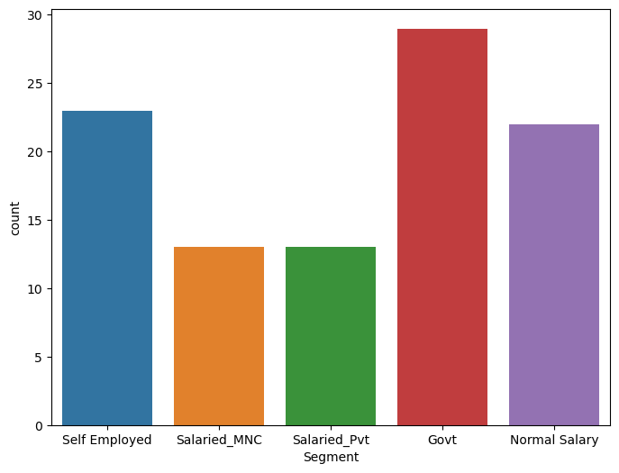

```python
plt.figure(figsize=(8, 6))
sns.countplot(x='Segment', data=customer)
plt.show()
```

```python
print("We can see from the countplot that number of distinct categories are", len(customer["Segment"].value_counts()))
```

```
We can see from the countplot that number of distinct categories are 5
```

# C. WHAT IS THE AVARAGE MONTHLY SPEND BY CUSTOMERS?

```python
spend.head()
```

|  | Customer | Month | Type | Amount |
| --- | --- | --- | --- | --- |
| 0 | A1 | 12-Jan-04 | JEWELLERY | 485470.80 |
| 1 | A1 | 3-Jan-04 | PETRO | 410556.13 |
| 2 | A1 | 15-Jan-04 | CLOTHES | 23740.46 |
| 3 | A1 | 25-Jan-04 | FOOD | 484342.47 |
| 4 | A1 | 17-Jan-05 | CAMERA | 369694.07 |

```python
#converting month column of "spend" table to data format
spend["Month"]=pd.to_datetime(spend["Month"])
```

```python
spend.head()
```

[output not shown]

```python
#creating new columns which show "Month" and "Year"
spend['Monthly'] = spend['Month'].apply(lambda x:pd.Timestamp.strftime(x,format="%B"))
spend['Yearly'] = spend['Month'].apply(lambda x:pd.Timestamp.strftime(x,format="%Y"))
```

```python
spend.head()
```

|  | Customer | Month | Type | Amount | Monthly | Yearly |
| --- | --- | --- | --- | --- | --- | --- |
| 0 | A1 | 2004-01-12 | JEWELLERY | 485470.80 | January | 2004 |
| 1 | A1 | 2004-01-03 | PETRO | 410556.13 | January | 2004 |
| 2 | A1 | 2004-01-15 | CLOTHES | 23740.46 | January | 2004 |
| 3 | A1 | 2004-01-25 | FOOD | 484342.47 | January | 2004 |
| 4 | A1 | 2005-01-17 | CAMERA | 369694.07 | January | 2005 |

```python
# Assuming 'Amount' is a numeric column
spend['Amount'] = pd.to_numeric(spend['Amount'], errors='coerce')  # Convert to numeric, handle errors

# Grouping by 'Yearly' and 'Monthly' and calculating the mean of 'Amount'
customer_spend_group = round(spend.groupby(['Yearly', 'Monthly'])['Amount'].mean(), 2)
```

```python
customer_spend_group
```

```
Yearly  Monthly
2004    April        235272.04
        February     221215.27
        January      251712.07
        March        232146.12
        May          217539.24
        November     270486.40
        September    310923.38
2005    April        252181.33
        August       233734.63
        December     147503.06
        February     229802.28
        January      292741.37
        July         229116.66
        June         262688.11
        May          245696.52
        November     286143.32
        October      194568.64
        September    188666.20
2006    April        232468.97
        August       240699.72
        December     270470.98
        February     253858.26
        January      282058.01
        July         287505.10
        June         177252.39
        March        247166.08
        May          236162.74
        November     182841.29
        October      236136.34
        September    158520.09
Name: Amount, dtype: float64
```

# D. WHAT IS THE AVERAGE MONTHLY REPAYMENT BY CUSTOMERS?

```python
repay.head()
```

|  | Customer | Month | Amount |
| --- | --- | --- | --- |
| 0 | A1 | 12-Jan-04 | 495414.75 |
| 1 | A1 | 3-Jan-04 | 245899.02 |
| 2 | A1 | 15-Jan-04 | 259490.06 |
| 3 | A1 | 25-Jan-04 | 437555.12 |
| 4 | A1 | 17-Jan-05 | 165972.88 |

```python
#converting "Month" column to date time format
repay["Month"] = pd.to_datetime(repay["Month"], format="%Y-%m")
```

```python
repay.head()
```

[output not shown]

```python
repay.dtypes
```

[output not shown]

```python
#creating new columns which show "Month" and "Year"
repay['Monthly'] = repay['Month'].apply(lambda x:pd.Timestamp.strftime(x,format="%B"))
repay['Yearly'] = repay['Month'].apply(lambda x:pd.Timestamp.strftime(x,format="%Y"))
```

```python
# Assuming 'Amount' is a numeric column
repay['Amount'] = pd.to_numeric(repay['Amount'], errors='coerce')  # Convert to numeric, handle errors

# Grouping by 'Yearly' and 'Monthly' and calculating the mean of 'Amount'
customer_repay_group = round(repay.groupby(['Yearly', 'Monthly'])['Amount'].mean(), 2)
```

```python
customer_repay_group
```

```
Yearly  Monthly
2004    April        259141.68
        February     256702.63
        January      243489.65
        March        252585.28
        May          226162.72
        November     209592.24
        September    184487.85
2005    April        212688.63
        August       264430.92
        December     320379.34
        February     238829.27
        January      240548.10
        July         239871.48
        June         210199.82
        May          263207.37
        November     256695.12
        October      219849.96
        September    247700.17
2006    April        275472.25
        August       224143.99
        December     252736.57
        February     284489.57
        January      293475.39
        July         257936.38
        June         251990.45
        March        240851.27
        May          256920.88
        November     199399.20
        October      260765.48
        September    262533.88
Name: Amount, dtype: float64
```

# E. IF THE MONTHLY RATE OF INTREST IS 2.9%,WHAT IS THE PROFIT FOR THE BANK FOR EACH MONTHS?

```python
#merging all the three tables. Alreaady merged customer and spend table in 'customer_spend'. Using "customer_spend" and "repay"
#table to form the final "customer_spend_repay" table
customer_spend_repay = pd.merge(left=customer_spend,right=repay,on="Customer",how="inner")
```

```python
customer_spend_repay.head()
```

|  | Customer | Age | City | Product | Limit | Company | Segment | Month_x | Type | Amount_x | Month_y | Amount_y | Monthly | Yearly |
| --- | --- | --- | --- | --- | --- | --- | --- | --- | --- | --- | --- | --- | --- | --- |
| 0 | A1 | 76.0 | BANGALORE | Gold | 500000.0 | C1 | Self Employed | 12-Jan-04 | JEWELLERY | 485470.8 | 1073865600000000000 | 495414.75 | January | 2004 |
| 1 | A1 | 76.0 | BANGALORE | Gold | 500000.0 | C1 | Self Employed | 12-Jan-04 | JEWELLERY | 485470.8 | 1073088000000000000 | 245899.02 | January | 2004 |
| 2 | A1 | 76.0 | BANGALORE | Gold | 500000.0 | C1 | Self Employed | 12-Jan-04 | JEWELLERY | 485470.8 | 1074124800000000000 | 259490.06 | January | 2004 |
| 3 | A1 | 76.0 | BANGALORE | Gold | 500000.0 | C1 | Self Employed | 12-Jan-04 | JEWELLERY | 485470.8 | 1074988800000000000 | 437555.12 | January | 2004 |
| 4 | A1 | 76.0 | BANGALORE | Gold | 500000.0 | C1 | Self Employed | 12-Jan-04 | JEWELLERY | 485470.8 | 1105920000000000000 | 165972.88 | January | 2005 |

```python
# renaming the columns for clearity
customer_spend_repay.rename(columns={"Amount_x":"Spend_Amount","Amount_y":"Repay_Amount"},inplace=True)
```

```python
customer_spend_repay.head()
```

|  | Customer | Age | City | Product | Limit | Company | Segment | Month_x | Type | Spend_Amount | Month_y | Repay_Amount | Monthly | Yearly |
| --- | --- | --- | --- | --- | --- | --- | --- | --- | --- | --- | --- | --- | --- | --- |
| 0 | A1 | 76.0 | BANGALORE | Gold | 500000.0 | C1 | Self Employed | 12-Jan-04 | JEWELLERY | 485470.8 | 1073865600000000000 | 495414.75 | January | 2004 |
| 1 | A1 | 76.0 | BANGALORE | Gold | 500000.0 | C1 | Self Employed | 12-Jan-04 | JEWELLERY | 485470.8 | 1073088000000000000 | 245899.02 | January | 2004 |
| 2 | A1 | 76.0 | BANGALORE | Gold | 500000.0 | C1 | Self Employed | 12-Jan-04 | JEWELLERY | 485470.8 | 1074124800000000000 | 259490.06 | January | 2004 |
| 3 | A1 | 76.0 | BANGALORE | Gold | 500000.0 | C1 | Self Employed | 12-Jan-04 | JEWELLERY | 485470.8 | 1074988800000000000 | 437555.12 | January | 2004 |
| 4 | A1 | 76.0 | BANGALORE | Gold | 500000.0 | C1 | Self Employed | 12-Jan-04 | JEWELLERY | 485470.8 | 1105920000000000000 | 165972.88 | January | 2005 |

```python
# Grouping the data based on "Yearly", "Monthly" columns to get the 'Spend_Amount' and 'Repay_Amount'
interest_group = customer_spend_repay.groupby(["Yearly", "Monthly"])[['Spend_Amount', 'Repay_Amount']].sum()
```

```python
interest_group
```

| Yearly | Monthly | Spend_Amount | Repay_Amount |
| --- | --- | --- | --- |
| 2004 | April | 1.194516e+08 | 2.285403e+08 |
|  | February | 7.613922e+07 | 1.602419e+08 |
|  | January | 1.088357e+09 | 1.699210e+09 |
|  | March | 5.594171e+07 | 8.974470e+07 |
|  | May | 8.800456e+07 | 1.411594e+08 |
|  | November | 5.504612e+07 | 7.860290e+07 |
|  | September | 5.144278e+07 | 8.016122e+07 |
| 2005 | April | 9.366405e+07 | 1.747894e+08 |
|  | August | 1.361400e+08 | 2.477449e+08 |
|  | December | 4.348638e+07 | 9.944533e+07 |
|  | February | 5.890557e+08 | 9.416163e+08 |
|  | January | 1.324129e+08 | 1.810333e+08 |
|  | July | 3.995653e+07 | 7.997268e+07 |
|  | June | 1.174019e+08 | 2.213774e+08 |
|  | May | 7.149030e+08 | 1.099197e+09 |
|  | November | 1.532278e+08 | 2.763119e+08 |
|  | October | 3.140993e+07 | 6.027830e+07 |
|  | September | 3.195551e+07 | 7.530449e+07 |
| 2006 | April | 3.229722e+08 | 6.093666e+08 |
|  | August | 5.849630e+07 | 7.167032e+07 |
|  | December | 4.585222e+07 | 7.087702e+07 |
|  | February | 1.654843e+08 | 2.903280e+08 |
|  | January | 5.127574e+07 | 8.974491e+07 |
|  | July | 1.444093e+08 | 2.245720e+08 |
|  | June | 5.302118e+07 | 6.914431e+07 |
|  | March | 7.393854e+08 | 1.115725e+09 |
|  | May | 3.297954e+08 | 5.434823e+08 |
|  | November | 1.124836e+08 | 1.355832e+08 |
|  | October | 5.285823e+07 | 7.890924e+07 |
|  | September | 5.395681e+07 | 8.083199e+07 |

```python
 # Monthly Profit = Monthly repayment – Monthly spend.
interest_group['Monthly Profit'] = interest_group['Repay_Amount'] - interest_group['Spend_Amount']
```

```python
interest_group
```

| Yearly | Monthly | Spend_Amount | Repay_Amount | Monthly Profit |
| --- | --- | --- | --- | --- |
| 2004 | April | 1.194516e+08 | 2.285403e+08 | 1.090887e+08 |
|  | February | 7.613922e+07 | 1.602419e+08 | 8.410268e+07 |
|  | January | 1.088357e+09 | 1.699210e+09 | 6.108525e+08 |
|  | March | 5.594171e+07 | 8.974470e+07 | 3.380298e+07 |
|  | May | 8.800456e+07 | 1.411594e+08 | 5.315485e+07 |
|  | November | 5.504612e+07 | 7.860290e+07 | 2.355678e+07 |
|  | September | 5.144278e+07 | 8.016122e+07 | 2.871844e+07 |
| 2005 | April | 9.366405e+07 | 1.747894e+08 | 8.112539e+07 |
|  | August | 1.361400e+08 | 2.477449e+08 | 1.116049e+08 |
|  | December | 4.348638e+07 | 9.944533e+07 | 5.595895e+07 |
|  | February | 5.890557e+08 | 9.416163e+08 | 3.525606e+08 |
|  | January | 1.324129e+08 | 1.810333e+08 | 4.862042e+07 |
|  | July | 3.995653e+07 | 7.997268e+07 | 4.001615e+07 |
|  | June | 1.174019e+08 | 2.213774e+08 | 1.039755e+08 |
|  | May | 7.149030e+08 | 1.099197e+09 | 3.842944e+08 |
|  | November | 1.532278e+08 | 2.763119e+08 | 1.230841e+08 |
|  | October | 3.140993e+07 | 6.027830e+07 | 2.886837e+07 |
|  | September | 3.195551e+07 | 7.530449e+07 | 4.334898e+07 |
| 2006 | April | 3.229722e+08 | 6.093666e+08 | 2.863944e+08 |
|  | August | 5.849630e+07 | 7.167032e+07 | 1.317402e+07 |
|  | December | 4.585222e+07 | 7.087702e+07 | 2.502480e+07 |
|  | February | 1.654843e+08 | 2.903280e+08 | 1.248436e+08 |
|  | January | 5.127574e+07 | 8.974491e+07 | 3.846917e+07 |
|  | July | 1.444093e+08 | 2.245720e+08 | 8.016271e+07 |
|  | June | 5.302118e+07 | 6.914431e+07 | 1.612313e+07 |
|  | March | 7.393854e+08 | 1.115725e+09 | 3.763400e+08 |
|  | May | 3.297954e+08 | 5.434823e+08 | 2.136869e+08 |
|  | November | 1.124836e+08 | 1.355832e+08 | 2.309955e+07 |
|  | October | 5.285823e+07 | 7.890924e+07 | 2.605102e+07 |
|  | September | 5.395681e+07 | 8.083199e+07 | 2.687518e+07 |

```python
#interest earned is 2.9% of Monthly Profit
interest_group['Interest Earned'] = (2.9* interest_group['Monthly Profit'])/100
```

```python
interest_group
```

| Yearly | Monthly | Spend_Amount | Repay_Amount | Monthly Profit | Interest Earned |
| --- | --- | --- | --- | --- | --- |
| 2004 | April | 1.194516e+08 | 2.285403e+08 | 1.090887e+08 | 3.163572e+06 |
|  | February | 7.613922e+07 | 1.602419e+08 | 8.410268e+07 | 2.438978e+06 |
|  | January | 1.088357e+09 | 1.699210e+09 | 6.108525e+08 | 1.771472e+07 |
|  | March | 5.594171e+07 | 8.974470e+07 | 3.380298e+07 | 9.802865e+05 |
|  | May | 8.800456e+07 | 1.411594e+08 | 5.315485e+07 | 1.541491e+06 |
|  | November | 5.504612e+07 | 7.860290e+07 | 2.355678e+07 | 6.831466e+05 |
|  | September | 5.144278e+07 | 8.016122e+07 | 2.871844e+07 | 8.328349e+05 |
| 2005 | April | 9.366405e+07 | 1.747894e+08 | 8.112539e+07 | 2.352636e+06 |
|  | August | 1.361400e+08 | 2.477449e+08 | 1.116049e+08 | 3.236542e+06 |
|  | December | 4.348638e+07 | 9.944533e+07 | 5.595895e+07 | 1.622810e+06 |
|  | February | 5.890557e+08 | 9.416163e+08 | 3.525606e+08 | 1.022426e+07 |
|  | January | 1.324129e+08 | 1.810333e+08 | 4.862042e+07 | 1.409992e+06 |
|  | July | 3.995653e+07 | 7.997268e+07 | 4.001615e+07 | 1.160468e+06 |
|  | June | 1.174019e+08 | 2.213774e+08 | 1.039755e+08 | 3.015290e+06 |
|  | May | 7.149030e+08 | 1.099197e+09 | 3.842944e+08 | 1.114454e+07 |
|  | November | 1.532278e+08 | 2.763119e+08 | 1.230841e+08 | 3.569438e+06 |
|  | October | 3.140993e+07 | 6.027830e+07 | 2.886837e+07 | 8.371827e+05 |
|  | September | 3.195551e+07 | 7.530449e+07 | 4.334898e+07 | 1.257121e+06 |
| 2006 | April | 3.229722e+08 | 6.093666e+08 | 2.863944e+08 | 8.305437e+06 |
|  | August | 5.849630e+07 | 7.167032e+07 | 1.317402e+07 | 3.820465e+05 |
|  | December | 4.585222e+07 | 7.087702e+07 | 2.502480e+07 | 7.257193e+05 |
|  | February | 1.654843e+08 | 2.903280e+08 | 1.248436e+08 | 3.620465e+06 |
|  | January | 5.127574e+07 | 8.974491e+07 | 3.846917e+07 | 1.115606e+06 |
|  | July | 1.444093e+08 | 2.245720e+08 | 8.016271e+07 | 2.324719e+06 |
|  | June | 5.302118e+07 | 6.914431e+07 | 1.612313e+07 | 4.675707e+05 |
|  | March | 7.393854e+08 | 1.115725e+09 | 3.763400e+08 | 1.091386e+07 |
|  | May | 3.297954e+08 | 5.434823e+08 | 2.136869e+08 | 6.196920e+06 |
|  | November | 1.124836e+08 | 1.355832e+08 | 2.309955e+07 | 6.698869e+05 |
|  | October | 5.285823e+07 | 7.890924e+07 | 2.605102e+07 | 7.554795e+05 |
|  | September | 5.395681e+07 | 8.083199e+07 | 2.687518e+07 | 7.793803e+05 |

# F. WHAT ARE THE TOP 5 PRODUCT TYPES?

```python
spend.head()
```

|  | Customer | Month | Type | Amount | Monthly | Yearly |
| --- | --- | --- | --- | --- | --- | --- |
| 0 | A1 | 2004-01-12 | JEWELLERY | 485470.80 | January | 2004 |
| 1 | A1 | 2004-01-03 | PETRO | 410556.13 | January | 2004 |
| 2 | A1 | 2004-01-15 | CLOTHES | 23740.46 | January | 2004 |
| 3 | A1 | 2004-01-25 | FOOD | 484342.47 | January | 2004 |
| 4 | A1 | 2005-01-17 | CAMERA | 369694.07 | January | 2005 |

```python
spend['Type'].value_counts().head()
```

```
Type
PETRO           200
FOOD            160
CAMERA          160
AIR TICKET      147
TRAIN TICKET    132
Name: count, dtype: int64
```

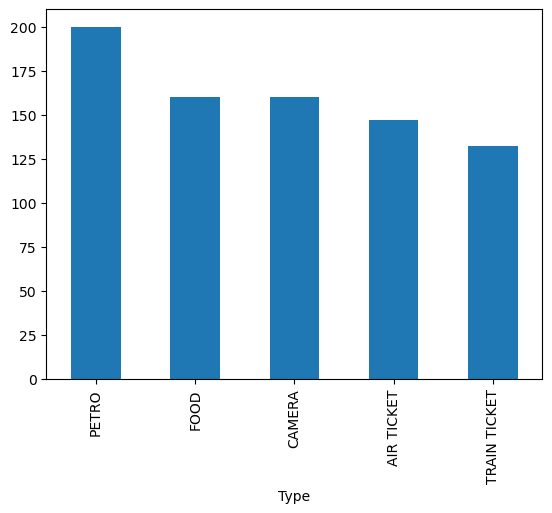

```python
spend['Type'].value_counts().head(5).plot(kind='bar')
plt.show()
```

# G. WHICH CITY IS HAVING MAXIMUM SPEND?

```python
customer_spend.head()
```

|  | Customer | Age | City | Product | Limit | Company | Segment | Month | Type | Amount |
| --- | --- | --- | --- | --- | --- | --- | --- | --- | --- | --- |
| 0 | A1 | 76.0 | BANGALORE | Gold | 500000.0 | C1 | Self Employed | 12-Jan-04 | JEWELLERY | 485470.80 |
| 1 | A1 | 76.0 | BANGALORE | Gold | 500000.0 | C1 | Self Employed | 3-Jan-04 | PETRO | 410556.13 |
| 2 | A1 | 76.0 | BANGALORE | Gold | 500000.0 | C1 | Self Employed | 15-Jan-04 | CLOTHES | 23740.46 |
| 3 | A1 | 76.0 | BANGALORE | Gold | 500000.0 | C1 | Self Employed | 25-Jan-04 | FOOD | 484342.47 |
| 4 | A1 | 76.0 | BANGALORE | Gold | 500000.0 | C1 | Self Employed | 17-Jan-05 | CAMERA | 369694.07 |

```python
city_spend = customer_spend.groupby("City")["Amount"].sum().sort_values(ascending=False)
```

```python
city_spend
```

```
City
COCHIN        45963513.50
CALCUTTA      41108132.30
BANGALORE     40461647.02
BOMBAY        28603127.38
CHENNAI       22128635.65
TRIVANDRUM    15337155.87
PATNA         15260586.97
DELHI         10918286.54
Name: Amount, dtype: float64
```

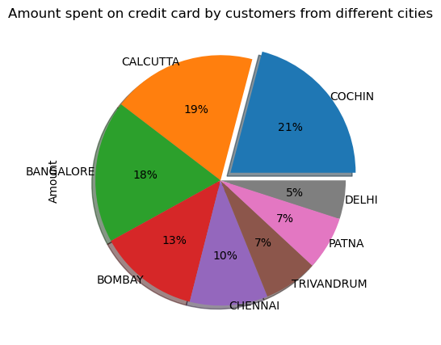

```python
plt.figure(figsize=(5,10))
city_spend.plot(kind="pie",autopct="%1.0f%%",shadow=True,labeldistance=1.0,explode=[0.1,0.0,0.0,0.0,0.0,0.0,0.0,0.0])
plt.title("Amount spent on credit card by customers from different cities")
plt.show()
```

```python
print("FROM ABOVE PIE CHART WE CAN SEE THAT COCHIN IS HAVING MAXIMUM SPEND.")
```

```
FROM ABOVE PIE CHART WE CAN SEE THAT COCHIN IS HAVING MAXIMUM SPEND.
```

# H. WHICH AGE GROUP IS SPENDING MORE MONEY?

```python
#creating new column "Age Group" with 8 bins between 18 to 88
customer_spend["Age Group"] =  pd.cut(customer_spend["Age"],bins=np.arange(18,88,8),labels=["18-26","26-34", "34-42" ,"42-50" ,"50-58","58-66","66-74","74-82"],include_lowest=True)
```

```python
customer_spend.head()
```

|  | Customer | Age | City | Product | Limit | Company | Segment | Month | Type | Amount | Age Group |
| --- | --- | --- | --- | --- | --- | --- | --- | --- | --- | --- | --- |
| 0 | A1 | 76.0 | BANGALORE | Gold | 500000.0 | C1 | Self Employed | 12-Jan-04 | JEWELLERY | 485470.80 | 74-82 |
| 1 | A1 | 76.0 | BANGALORE | Gold | 500000.0 | C1 | Self Employed | 3-Jan-04 | PETRO | 410556.13 | 74-82 |
| 2 | A1 | 76.0 | BANGALORE | Gold | 500000.0 | C1 | Self Employed | 15-Jan-04 | CLOTHES | 23740.46 | 74-82 |
| 3 | A1 | 76.0 | BANGALORE | Gold | 500000.0 | C1 | Self Employed | 25-Jan-04 | FOOD | 484342.47 | 74-82 |
| 4 | A1 | 76.0 | BANGALORE | Gold | 500000.0 | C1 | Self Employed | 17-Jan-05 | CAMERA | 369694.07 | 74-82 |

```python
#grouping data based on "Age Group" and finding the amount spend by each age group and arranging in descending oreder
age_spend = customer_spend.groupby("Age Group")['Amount'].sum().sort_values(ascending=False)
```

```python
age_spend
```

```
Age Group
42-50    53242390.70
34-42    38037826.50
26-34    30553459.81
18-26    25233896.65
50-58    22454066.68
74-82    19770884.32
66-74    17705877.44
58-66    12782683.13
Name: Amount, dtype: float64
```

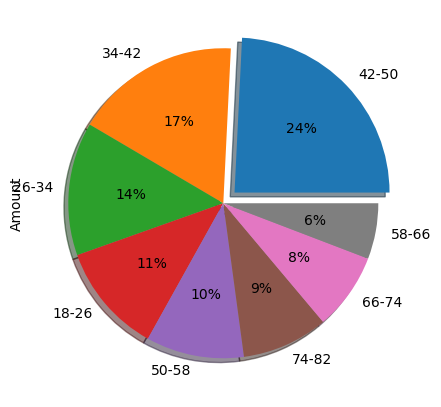

```python
plt.figure(figsize=(5,10))
age_spend.plot(kind = "pie",autopct="%1.0f%%",explode=[0.1,0.0,0.0,0.0,0.0,0.0,0.0,0.0],shadow=True)
plt.show()
```

```python
print("From the pie chart shown above we can say that age group 42 - 50 is spending more money")
```

```
From the pie chart shown above we can say that age group 42 - 50 is spending more money
```

# I. WHO ARE THE TOP 10 CUSTOMERS IN TERMS OF REPAYMENTS?

```python
customer_repay.head()
```

|  | Customer | Month | Amount | Age | City | Product | Limit | Company | Segment |
| --- | --- | --- | --- | --- | --- | --- | --- | --- | --- |
| 0 | A1 | 12-Jan-04 | 495414.75 | 76.0 | BANGALORE | Gold | 500000.0 | C1 | Self Employed |
| 1 | A1 | 3-Jan-04 | 245899.02 | 76.0 | BANGALORE | Gold | 500000.0 | C1 | Self Employed |
| 2 | A1 | 15-Jan-04 | 259490.06 | 76.0 | BANGALORE | Gold | 500000.0 | C1 | Self Employed |
| 3 | A1 | 25-Jan-04 | 437555.12 | 76.0 | BANGALORE | Gold | 500000.0 | C1 | Self Employed |
| 4 | A1 | 17-Jan-05 | 165972.88 | 76.0 | BANGALORE | Gold | 500000.0 | C1 | Self Employed |

```python
#grouping based on "Customer" column to find top 10 customers
customer_repay.groupby("Customer")[["Amount"]].sum().sort_values(by="Amount",ascending=False).head(10)
```

| Customer | Amount |
| --- | --- |
| A61 | 10539142.91 |
| A60 | 9876290.74 |
| A13 | 9572000.66 |
| A43 | 8489871.46 |
| A45 | 8448334.87 |
| A12 | 8334760.16 |
| A14 | 7943268.63 |
| A44 | 7744730.12 |
| A39 | 7622483.30 |
| A42 | 7615460.86 |

# 3. CALCULATE THE CITY WISE SPEND ON EACH PRODUCT ON YEARLY BASIS. ALSO INCLUDE A GRAPHICAL REPRESENTATION FOR THE SAME.

```python
customer_spend.head()
```

|  | Customer | Age | City | Product | Limit | Company | Segment | Month | Type | Amount | Age Group |
| --- | --- | --- | --- | --- | --- | --- | --- | --- | --- | --- | --- |
| 0 | A1 | 76.0 | BANGALORE | Gold | 500000.0 | C1 | Self Employed | 12-Jan-04 | JEWELLERY | 485470.80 | 74-82 |
| 1 | A1 | 76.0 | BANGALORE | Gold | 500000.0 | C1 | Self Employed | 3-Jan-04 | PETRO | 410556.13 | 74-82 |
| 2 | A1 | 76.0 | BANGALORE | Gold | 500000.0 | C1 | Self Employed | 15-Jan-04 | CLOTHES | 23740.46 | 74-82 |
| 3 | A1 | 76.0 | BANGALORE | Gold | 500000.0 | C1 | Self Employed | 25-Jan-04 | FOOD | 484342.47 | 74-82 |
| 4 | A1 | 76.0 | BANGALORE | Gold | 500000.0 | C1 | Self Employed | 17-Jan-05 | CAMERA | 369694.07 | 74-82 |

```python
#converting "Month" column to date time
customer_spend["Month"] = pd.to_datetime(customer_spend["Month"],format="%y-%m")
```

```python
#creating new column "year"
customer_spend['Year'] = customer_spend['Month'].apply(lambda x:pd.Timestamp.strftime(x,format="%Y"))
```

```python
customer_spend.head()
```

|  | Customer | Age | City | Product | Limit | Company | Segment | Month | Type | Amount | Age Group | Year |
| --- | --- | --- | --- | --- | --- | --- | --- | --- | --- | --- | --- | --- |
| 0 | A1 | 76.0 | BANGALORE | Gold | 500000.0 | C1 | Self Employed | 2004-01-12 | JEWELLERY | 485470.80 | 74-82 | 2004 |
| 1 | A1 | 76.0 | BANGALORE | Gold | 500000.0 | C1 | Self Employed | 2004-01-03 | PETRO | 410556.13 | 74-82 | 2004 |
| 2 | A1 | 76.0 | BANGALORE | Gold | 500000.0 | C1 | Self Employed | 2004-01-15 | CLOTHES | 23740.46 | 74-82 | 2004 |
| 3 | A1 | 76.0 | BANGALORE | Gold | 500000.0 | C1 | Self Employed | 2004-01-25 | FOOD | 484342.47 | 74-82 | 2004 |
| 4 | A1 | 76.0 | BANGALORE | Gold | 500000.0 | C1 | Self Employed | 2005-01-17 | CAMERA | 369694.07 | 74-82 | 2005 |

```python
customer_spend_pivot = pd.pivot_table(data = customer_spend,index=["City","Year"],columns='Product',aggfunc="sum",values="Amount")
```

```python
customer_spend_pivot
```

| City | Product Year | Gold | Platimum | Silver |
| --- | --- | --- | --- | --- |
| BANGALORE | 2004 | 9289878.54 | 1112732.30 | 1291852.58 |
|  | 2005 | 12892362.99 | 912284.97 | 830612.34 |
|  | 2006 | 12030611.09 | 685831.27 | 1415480.94 |
| BOMBAY | 2004 | 6987853.53 | 897264.94 | 532089.03 |
|  | 2005 | 8983018.28 | 711804.94 | 508988.54 |
|  | 2006 | 7917144.31 | 972130.01 | 1092833.80 |
| CALCUTTA | 2004 | 7477140.98 | 2037690.30 | 500006.00 |
|  | 2005 | 10303355.80 | 4434696.31 | 440147.06 |
|  | 2006 | 11167532.77 | 3589606.66 | 1157956.42 |
| CHENNAI | 2004 | 1059618.50 | 3535652.38 | 282056.86 |
|  | 2005 | 3740945.58 | 5053956.32 | 377184.49 |
|  | 2006 | 2704288.62 | 5024923.40 | 350009.50 |
| COCHIN | 2004 | 7315850.15 | 3419904.07 | 814229.62 |
|  | 2005 | 12110613.03 | 4960921.71 | 652269.38 |
|  | 2006 | 10499142.38 | 4920592.29 | 1269990.87 |
| DELHI | 2004 | 2806495.00 | 283512.89 | 768172.30 |
|  | 2005 | 1964845.27 | 494157.86 | 612311.21 |
|  | 2006 | 2957103.32 | 176788.72 | 854899.97 |
| PATNA | 2004 | 2072567.90 | 1113069.60 | 756684.10 |
|  | 2005 | 3252615.77 | 2883231.07 | 950094.19 |
|  | 2006 | 2276181.69 | 1256137.65 | 700005.00 |
| TRIVANDRUM | 2004 | 2415102.84 | 2161676.67 | 209667.48 |
|  | 2005 | 1240375.85 | 3601443.30 | 269912.99 |
|  | 2006 | 2735710.87 | 2147403.75 | 555862.12 |

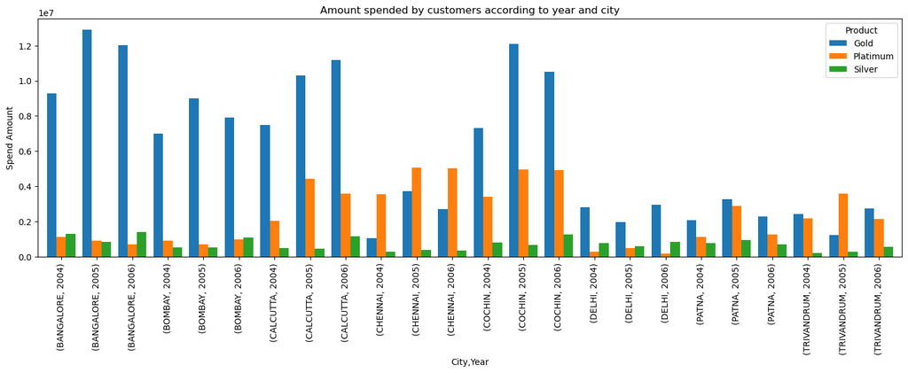

```python
customer_spend_pivot.plot(kind="bar",figsize=(18,5),width=0.8)
plt.ylabel("Spend Amount")
plt.title("Amount spended by customers according to year and city")
plt.show()
```

# 4. CREATE GRAPHS FOR

# A. MONTHLY COMPARISON OF TOTAL SPENDS, CITY WISE

```python
customer_spend.head()
```

|  | Customer | Age | City | Product | Limit | Company | Segment | Month | Type | Amount | Age Group | Year |
| --- | --- | --- | --- | --- | --- | --- | --- | --- | --- | --- | --- | --- |
| 0 | A1 | 76.0 | BANGALORE | Gold | 500000.0 | C1 | Self Employed | 2004-01-12 | JEWELLERY | 485470.80 | 74-82 | 2004 |
| 1 | A1 | 76.0 | BANGALORE | Gold | 500000.0 | C1 | Self Employed | 2004-01-03 | PETRO | 410556.13 | 74-82 | 2004 |
| 2 | A1 | 76.0 | BANGALORE | Gold | 500000.0 | C1 | Self Employed | 2004-01-15 | CLOTHES | 23740.46 | 74-82 | 2004 |
| 3 | A1 | 76.0 | BANGALORE | Gold | 500000.0 | C1 | Self Employed | 2004-01-25 | FOOD | 484342.47 | 74-82 | 2004 |
| 4 | A1 | 76.0 | BANGALORE | Gold | 500000.0 | C1 | Self Employed | 2005-01-17 | CAMERA | 369694.07 | 74-82 | 2005 |

```python
#creating new column "Monthly"
customer_spend['Monthly'] = customer_spend['Month'].apply(lambda x:pd.Timestamp.strftime(x,format="%B"))
```

```python
customer_spend.head()
```

|  | Customer | Age | City | Product | Limit | Company | Segment | Month | Type | Amount | Age Group | Year | Monthly |
| --- | --- | --- | --- | --- | --- | --- | --- | --- | --- | --- | --- | --- | --- |
| 0 | A1 | 76.0 | BANGALORE | Gold | 500000.0 | C1 | Self Employed | 2004-01-12 | JEWELLERY | 485470.80 | 74-82 | 2004 | January |
| 1 | A1 | 76.0 | BANGALORE | Gold | 500000.0 | C1 | Self Employed | 2004-01-03 | PETRO | 410556.13 | 74-82 | 2004 | January |
| 2 | A1 | 76.0 | BANGALORE | Gold | 500000.0 | C1 | Self Employed | 2004-01-15 | CLOTHES | 23740.46 | 74-82 | 2004 | January |
| 3 | A1 | 76.0 | BANGALORE | Gold | 500000.0 | C1 | Self Employed | 2004-01-25 | FOOD | 484342.47 | 74-82 | 2004 | January |
| 4 | A1 | 76.0 | BANGALORE | Gold | 500000.0 | C1 | Self Employed | 2005-01-17 | CAMERA | 369694.07 | 74-82 | 2005 | January |

```python
#grouping data based on "Monthly" and "City" columns
month_city = customer_spend.groupby(["Monthly","City"])[["Amount"]].sum().sort_index().reset_index()
```

```python
#creating pivot table based on "Monthly" and "City" columns
month_city =pd.pivot_table(data=customer_spend,values='Amount',index='City',columns='Monthly',aggfunc='sum')
```

```python
month_city
```

| Monthly City | April | August | December | February | January | July | June | March | May | November | October | September |
| --- | --- | --- | --- | --- | --- | --- | --- | --- | --- | --- | --- | --- |
| BANGALORE | 4207980.48 | 695061.95 | 422167.24 | 6734494.76 | 9041796.84 | 2228217.69 | 1330685.90 | 5362903.07 | 6383115.13 | 2260603.07 | 1091602.61 | 703018.28 |
| BOMBAY | 1873785.01 | 1066744.75 | 140040.71 | 4276988.30 | 5948993.33 | 177726.32 | 1172594.97 | 5227850.50 | 3891945.60 | 2872049.40 | 676005.70 | 1278402.79 |
| CALCUTTA | 3457507.95 | 1548354.02 | 55001.50 | 8150545.61 | 9064864.90 | 2234573.27 | 2293045.81 | 4939040.04 | 5578246.87 | 2078880.93 | 196357.83 | 1511713.57 |
| CHENNAI | 2518656.99 | 305875.97 | 223628.27 | 4385815.95 | 4466961.36 | 693825.77 | 1244242.16 | 3183643.71 | 2856199.62 | 1347779.28 | 156247.17 | 745759.40 |
| COCHIN | 3882744.94 | 2317306.61 | 909533.05 | 5747886.38 | 11714373.54 | 1290897.30 | 2495745.07 | 5645146.53 | 6581085.69 | 3127999.60 | 868551.89 | 1382242.90 |
| DELHI | 777240.75 | 155402.16 | 842342.02 | 1494064.06 | 2714261.45 | 50001.50 | 511276.09 | 2267149.02 | 1600322.07 | 391610.96 | 64615.46 | 50001.00 |
| PATNA | 2338179.53 | 419383.64 | 50000.00 | 2353333.55 | 4916205.55 | 50000.00 | 746186.13 | 1437166.61 | 2136586.80 | 413677.87 | 329537.34 | 70329.95 |
| TRIVANDRUM | 1199293.45 | 453773.94 | 640922.26 | 2857123.89 | 3704336.99 | 260484.50 | 400336.83 | 2392316.51 | 2813534.48 | 143387.40 | 285581.92 | 186063.70 |

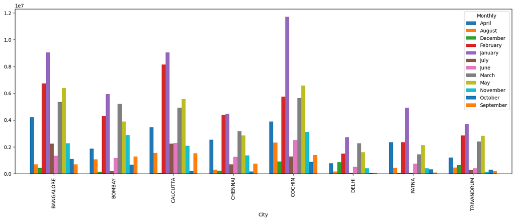

```python
month_city.plot(kind="bar",figsize=(18,6),width=0.8)
plt.show()
```

# B. COMPARISON OF YEARLY SPEND ON AIR TICKETS

```python
customer_spend.head()
```

|  | Customer | Age | City | Product | Limit | Company | Segment | Month | Type | Amount | Age Group | Year | Monthly |
| --- | --- | --- | --- | --- | --- | --- | --- | --- | --- | --- | --- | --- | --- |
| 0 | A1 | 76.0 | BANGALORE | Gold | 500000.0 | C1 | Self Employed | 2004-01-12 | JEWELLERY | 485470.80 | 74-82 | 2004 | January |
| 1 | A1 | 76.0 | BANGALORE | Gold | 500000.0 | C1 | Self Employed | 2004-01-03 | PETRO | 410556.13 | 74-82 | 2004 | January |
| 2 | A1 | 76.0 | BANGALORE | Gold | 500000.0 | C1 | Self Employed | 2004-01-15 | CLOTHES | 23740.46 | 74-82 | 2004 | January |
| 3 | A1 | 76.0 | BANGALORE | Gold | 500000.0 | C1 | Self Employed | 2004-01-25 | FOOD | 484342.47 | 74-82 | 2004 | January |
| 4 | A1 | 76.0 | BANGALORE | Gold | 500000.0 | C1 | Self Employed | 2005-01-17 | CAMERA | 369694.07 | 74-82 | 2005 | January |

```python
air_tickets = customer_spend.groupby(["Year","Type"])[["Amount"]].sum().reset_index()
```

```python
filtered = air_tickets.loc[air_tickets["Type"]=="AIR TICKET"]
```

```python
filtered
```

|  | Year | Type | Amount |
| --- | --- | --- | --- |
| 0 | 2004 | AIR TICKET | 4357225.35 |
| 15 | 2005 | AIR TICKET | 10550152.21 |
| 30 | 2006 | AIR TICKET | 5248469.56 |

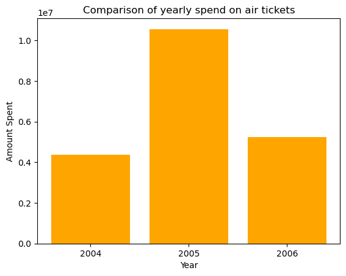

```python
plt.bar(filtered["Year"],height=filtered["Amount"],color="orange")
plt.xlabel("Year")
plt.ylabel("Amount Spent")
plt.title("Comparison of yearly spend on air tickets")
plt.show()
```

# C. COMPARISION OF MONTHLY SPEND FOR EACH PRODUCT (LOOK FOR ANY SEASONALITY THAT EXIST IN TERMS OF SPEND)

```python
customer_spend.head()
```

|  | Customer | Age | City | Product | Limit | Company | Segment | Month | Type | Amount | Age Group | Year | Monthly |
| --- | --- | --- | --- | --- | --- | --- | --- | --- | --- | --- | --- | --- | --- |
| 0 | A1 | 76.0 | BANGALORE | Gold | 500000.0 | C1 | Self Employed | 2004-01-12 | JEWELLERY | 485470.80 | 74-82 | 2004 | January |
| 1 | A1 | 76.0 | BANGALORE | Gold | 500000.0 | C1 | Self Employed | 2004-01-03 | PETRO | 410556.13 | 74-82 | 2004 | January |
| 2 | A1 | 76.0 | BANGALORE | Gold | 500000.0 | C1 | Self Employed | 2004-01-15 | CLOTHES | 23740.46 | 74-82 | 2004 | January |
| 3 | A1 | 76.0 | BANGALORE | Gold | 500000.0 | C1 | Self Employed | 2004-01-25 | FOOD | 484342.47 | 74-82 | 2004 | January |
| 4 | A1 | 76.0 | BANGALORE | Gold | 500000.0 | C1 | Self Employed | 2005-01-17 | CAMERA | 369694.07 | 74-82 | 2005 | January |

```python
#creating pivot table based on "Monthly" and "Product" columns
product_wise = pd.pivot_table(data=customer_spend,index='Product',columns='Monthly',values='Amount',aggfunc='sum')
```

```python
product_wise
```

| Monthly Product | April | August | December | February | January | July | June | March | May | November | October | September |
| --- | --- | --- | --- | --- | --- | --- | --- | --- | --- | --- | --- | --- |
| Gold | 13170572.59 | 4954030.42 | 2332940.96 | 24779179.55 | 32413831.83 | 5167416.37 | 6538862.64 | 19256972.48 | 21548169.76 | 9203267.46 | 3018223.38 | 3816887.62 |
| Platimum | 5182493.86 | 1714762.80 | 750156.19 | 9134054.58 | 14951578.51 | 1288156.26 | 2965712.71 | 7288837.68 | 8151926.49 | 2741618.42 | 550275.04 | 1667840.84 |
| Silver | 1902322.65 | 293109.82 | 200537.90 | 2087018.37 | 4206383.62 | 530153.72 | 689537.61 | 3909405.83 | 2140940.01 | 691102.63 | 100001.50 | 442803.13 |

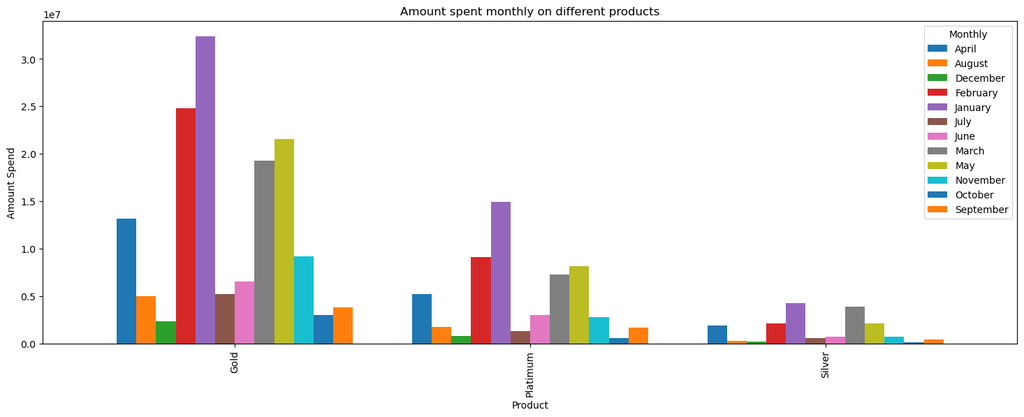

```python
product_wise.plot(kind="bar",figsize=(18,6),width=0.8)
plt.ylabel("Amount Spend")
plt.title("Amount spent monthly on different products")
plt.show()
```

# We can see from the above graph that the sales are high for all the Products during the months:

January, February, March, April, May Out of these months,highest sales are in January

# 5. Write user defined PYTHON function to perform the following analysis: You need to find top 10 customers for each city in terms of their repayment amount by different products and by different time periods i.e. year or month. The user should be able to specify the product (Gold/Silver/Platinum) and time period (yearly or monthly) and the function should automatically take these inputs while identifying the top 10 customers.

```python
customer_repay.head()
```

|  | Customer | Month | Amount | Age | City | Product | Limit | Company | Segment |
| --- | --- | --- | --- | --- | --- | --- | --- | --- | --- |
| 0 | A1 | 12-Jan-04 | 495414.75 | 76.0 | BANGALORE | Gold | 500000.0 | C1 | Self Employed |
| 1 | A1 | 3-Jan-04 | 245899.02 | 76.0 | BANGALORE | Gold | 500000.0 | C1 | Self Employed |
| 2 | A1 | 15-Jan-04 | 259490.06 | 76.0 | BANGALORE | Gold | 500000.0 | C1 | Self Employed |
| 3 | A1 | 25-Jan-04 | 437555.12 | 76.0 | BANGALORE | Gold | 500000.0 | C1 | Self Employed |
| 4 | A1 | 17-Jan-05 | 165972.88 | 76.0 | BANGALORE | Gold | 500000.0 | C1 | Self Employed |

```python
# converting 'Month' column to date time format
customer_repay['Month'] = pd.to_datetime(customer_repay['Month'],format="%y-%m")
```

```python
#creating new column "Monthly" and "Yearly" using already existing 'Month' column
customer_repay['Monthly'] = customer_repay['Month'].apply(lambda x:pd.Timestamp.strftime(x,format="%B"))
customer_repay['Yearly'] = customer_repay['Month'].apply(lambda x:pd.Timestamp.strftime(x,format="%Y"))
```

```python
def summary_report(product,timeperiod):
    print('Give the product name and timeperiod for which you want the data')
    if product.lower()=='gold' and timeperiod.lower()=='monthly':
        pivot = customer_repay.pivot_table(index=['Product','City','Customer'],columns='Monthly',aggfunc='sum',values='Amount')
        result = pivot.loc[('Gold',['BANGALORE','COCHIN','CALCUTTA','BOMBAY','CHENNAI','TRIVANDRUM','PATNA','DELHI']),:]
    elif product.lower()=='gold' and timeperiod.lower()=='yearly':
        pivot = customer_repay.pivot_table(index=['Product','City','Customer'],columns='Yearly',aggfunc='sum',values='Amount')
        result = pivot.loc[('Gold',['BANGALORE','COCHIN','CALCUTTA','BOMBAY','CHENNAI','TRIVANDRUM','PATNA','DELHI']),:]
    elif product.lower()=='silver' and timeperiod.lower()=='monthly':
        pivot = customer_repay.pivot_table(index=['Product','City','Customer'],columns='Monthly',aggfunc='sum',values='Amount')
        result = pivot.loc[('Silver',['BANGALORE','COCHIN','CALCUTTA','BOMBAY','CHENNAI','TRIVANDRUM','PATNA','DELHI']),:]
    elif product.lower()=='silver' and timeperiod.lower()=='yearly':
        pivot = customer_repay.pivot_table(index=['Product','City','Customer'],columns='Yearly',aggfunc='sum',values='Amount')
        result = pivot.loc[('Silver',['BANGALORE','COCHIN','CALCUTTA','BOMBAY','CHENNAI','TRIVANDRUM','PATNA','DELHI']),:]
    if product.lower()=='platinum' and timeperiod.lower()=='monthly':
        pivot = customer_repay.pivot_table(index=['Product','City','Customer'],columns='Monthly',aggfunc='sum',values='Amount')
        result = pivot.loc[('Platinum',['BANGALORE','COCHIN','CALCUTTA','BOMBAY','CHENNAI','TRIVANDRUM','PATNA','DELHI']),:]
    elif product.lower()=='platinum' and timeperiod.lower()=='yearly':
        pivot = customer_repay.pivot_table(index=['Product','City','Customer'],columns='Yearly',aggfunc='sum',values='Amount')
        result = pivot.loc[('Platinum',['BANGALORE','COCHIN','CALCUTTA','BOMBAY','CHENNAI','TRIVANDRUM','PATNA','DELHI']),:]
    return result
```

```python
summary_report('gold','monthly')
```

```
Give the product name and timeperiod for which you want the data
```

| Product | City | Monthly Customer | April | August | December | February | January | July | June | March | May | November | October | September |
| --- | --- | --- | --- | --- | --- | --- | --- | --- | --- | --- | --- | --- | --- | --- |
| Gold | BANGALORE | A1 | 508949.16 | NaN | NaN | 781873.80 | 2407806.29 | 297176.74 | NaN | NaN | NaN | 571458.18 | NaN | 186427.50 |
|  |  | A13 | 494392.40 | 873304.51 | NaN | 2049808.15 | 2014186.98 | 424603.55 | 837101.91 | 1183569.05 | 632600.75 | 622592.45 | NaN | 439840.91 |
|  |  | A14 | 812582.20 | 198623.13 | 388821.96 | 1482923.34 | 993114.87 | 41962.19 | 41128.98 | 1682886.51 | 1418286.63 | 420638.02 | NaN | 462300.80 |
|  |  | A30 | 425694.16 | NaN | NaN | 1321469.80 | 608066.49 | NaN | 72609.24 | 599331.38 | 3086549.14 | NaN | NaN | 19761.75 |
|  |  | A43 | 612541.80 | NaN | NaN | 763846.93 | 1978038.15 | 803935.53 | 23525.91 | 1378774.72 | 2058983.99 | 454364.16 | 415860.27 | NaN |
|  |  | A63 | NaN | NaN | NaN | NaN | 372179.26 | NaN | NaN | NaN | 416676.34 | 211117.12 | NaN | NaN |
|  |  | A81 | NaN | NaN | NaN | NaN | NaN | NaN | NaN | 207780.32 | NaN | NaN | NaN | NaN |
|  |  | A88 | NaN | NaN | NaN | NaN | NaN | NaN | NaN | 146821.30 | NaN | NaN | NaN | NaN |
|  |  | A92 | 459105.69 | NaN | NaN | NaN | NaN | NaN | NaN | NaN | NaN | NaN | NaN | NaN |
|  | COCHIN | A11 | 958466.08 | 332677.61 | NaN | 1069789.26 | 958556.39 | 128484.37 | NaN | 508638.02 | 1354322.30 | NaN | NaN | NaN |
|  |  | A16 | 338710.86 | NaN | NaN | 331143.85 | 1071852.72 | 367100.15 | 92055.06 | 886861.02 | 572216.09 | 260514.95 | NaN | 339373.25 |
|  |  | A32 | 333042.82 | 99528.43 | NaN | 851127.91 | NaN | 137150.37 | 284410.26 | 540858.16 | 312176.83 | NaN | NaN | NaN |
|  |  | A45 | 1435443.21 | 431769.44 | 410935.52 | 1241580.90 | 2033076.43 | NaN | 303151.38 | 869686.35 | 1657916.98 | NaN | NaN | 64774.66 |
|  |  | A61 | 3412860.60 | 197804.13 | NaN | 1345911.54 | 1755251.93 | 441593.08 | NaN | 382632.66 | 1819382.29 | 423828.84 | 289863.84 | 470014.00 |
|  |  | A65 | NaN | NaN | NaN | NaN | 468922.60 | NaN | NaN | NaN | 230667.34 | NaN | NaN | NaN |
|  |  | A90 | 109931.32 | NaN | NaN | NaN | NaN | NaN | NaN | NaN | NaN | NaN | NaN | NaN |
|  |  | A94 | NaN | NaN | NaN | NaN | 153465.89 | NaN | NaN | NaN | NaN | NaN | NaN | NaN |
|  | CALCUTTA | A10 | 478747.41 | NaN | NaN | 652033.51 | 1091589.54 | 358194.65 | NaN | 720391.63 | 394690.78 | NaN | NaN | NaN |
|  |  | A15 | NaN | 17981.25 | NaN | 516544.51 | 1051502.61 | NaN | 49334.38 | 1738696.08 | 1953768.97 | NaN | 227585.03 | NaN |
|  |  | A29 | NaN | 534103.41 | NaN | 627147.67 | 1474900.52 | NaN | NaN | 1269579.93 | 2612139.63 | NaN | NaN | NaN |
|  |  | A31 | 13054.67 | NaN | NaN | 962656.24 | NaN | 130109.14 | NaN | 845269.25 | 1432949.95 | NaN | NaN | NaN |
|  |  | A60 | 2397565.91 | 735660.40 | NaN | 1403731.08 | 2465584.81 | 273877.36 | 657931.74 | 109367.55 | 1189900.27 | 294357.01 | NaN | 348314.61 |
|  |  | A89 | 497237.97 | NaN | NaN | NaN | NaN | NaN | NaN | NaN | NaN | NaN | NaN | NaN |
|  | BOMBAY | A12 | 601326.07 | 120471.17 | NaN | 1978117.59 | 1220387.18 | 1201928.94 | 526225.82 | 1001134.17 | 1048233.62 | NaN | 347528.59 | 289407.01 |
|  |  | A17 | 391463.29 | 98341.04 | 479227.30 | 374865.01 | 761645.74 | 118112.45 | 257937.78 | 2007441.50 | 382881.69 | NaN | 412459.19 | NaN |
|  |  | A42 | 173199.87 | NaN | NaN | 476213.23 | 2516249.24 | NaN | NaN | 579721.80 | 3305341.39 | 362899.70 | 197897.82 | 3937.81 |
|  |  | A62 | 1115760.01 | NaN | NaN | 478764.07 | 996722.42 | NaN | NaN | 546251.18 | 758067.14 | 798121.60 | 276130.73 | NaN |
|  |  | A91 | 247781.00 | NaN | NaN | NaN | NaN | NaN | NaN | NaN | NaN | NaN | NaN | NaN |
|  | CHENNAI | A27 | 379529.81 | 472123.57 | 136860.63 | 841114.02 | 1215350.93 | 241912.50 | 484419.68 | 976107.81 | 1855518.11 | 409963.50 | NaN | NaN |
|  |  | A67 | NaN | NaN | NaN | NaN | 67845.60 | NaN | NaN | NaN | 55638.77 | NaN | NaN | NaN |
|  | TRIVANDRUM | A28 | 115326.71 | 437823.07 | 451630.26 | 968709.79 | 1034461.46 | 380460.40 | NaN | 1547067.86 | 2233253.41 | NaN | NaN | NaN |
|  | PATNA | A26 | 558432.60 | 398164.37 | 417177.67 | 1298000.32 | 1129827.37 | 213185.89 | NaN | 416810.29 | 2215839.66 | 255915.07 | 351333.85 | NaN |
|  |  | A66 | NaN | NaN | NaN | NaN | 477039.78 | NaN | NaN | NaN | 113094.58 | NaN | NaN | NaN |
|  |  | A95 | NaN | NaN | NaN | NaN | 369405.96 | NaN | NaN | NaN | NaN | NaN | NaN | NaN |
|  | DELHI | A44 | 346650.76 | 539494.72 | 79696.21 | 745752.19 | 2415712.91 | 501962.99 | NaN | 696222.43 | 1988158.24 | 431079.67 | NaN | NaN |
|  |  | A64 | NaN | NaN | 212614.48 | NaN | NaN | NaN | NaN | NaN | 110614.61 | NaN | NaN | NaN |
|  |  | A82 | NaN | NaN | NaN | NaN | NaN | NaN | NaN | 342200.74 | NaN | NaN | NaN | NaN |
|  |  | A93 | NaN | NaN | NaN | NaN | 342326.14 | NaN | NaN | NaN | NaN | NaN | NaN | NaN |